# Bio

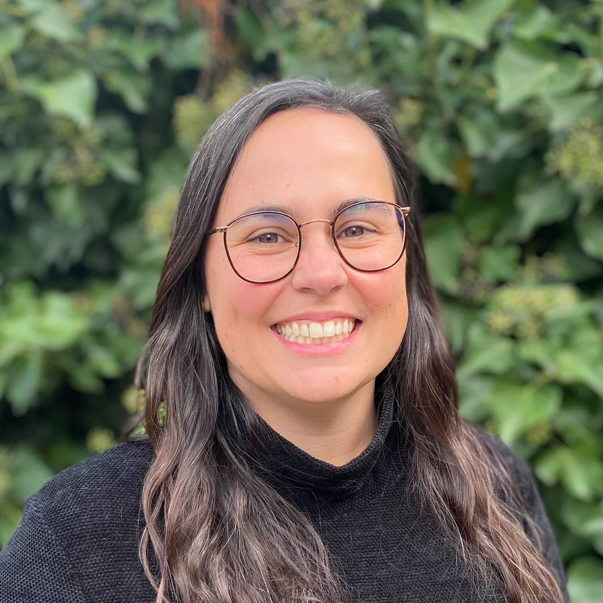

Jess is an evolutionary scientist based at Atlas of Living Australia, with a postdoc on species delimitation methods and PhD on diversification at micro/macro scales. She is also affiliated with the Division of Ecology and Evolution, ANU. Jess brings her experience in R to improve the readability, data standardisation and performance of EcoCommons’ platform ecological modelling algorithms. Jess is a strong advocate for diversity in STEMM.

## Posts

[Quantify geographic sampling bias with sampbias}](https://labs.ala.org.au/posts/2022-07-22_sample-bias/)  
*Human biases play a large role in the data we collect about species. Here we show a simple method to quantify the bias of roads, cities, rivers and airports on species observations of legless lizards in the Northern Territory*  
[Multiple colour scales in choropleth maps with ggnewscale}](https://labs.ala.org.au/posts/2022-05-23-ggnewscale/)  
*Using multiple colour scales can be a great way to visually differentiate between geographic categories on a map. Here, we demonstrate this by creating a choropleth map to represent the density of plant records from the ALA across bioregions in Australia, and add multiple colour scales to differentiate marine and terrestrial records*  
[Download plant species data by hexagon to make a 3D hex map](https://labs.ala.org.au/posts/2022-05-17_3d-map/)  
*Making plots eye-catching can be useful for science communication. Here, we show how to make 3D plots in R with the `rayshader` package by visualising the number of species identified from ALA observations since 2020*